# Calculating Gen1 IQ

## Show the IQ data with age of the subject when the IQ was taken. Filter out records where the age or the IQ is outside of the desired window.

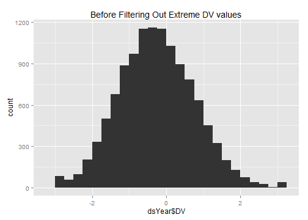

```r
#Filter out records with undesired DV values
qplot(dsYear$DV, binwidth=.25, main="Before Filtering Out Extreme DV values")
```

```r
dsYear <- dsYear[!is.na(dsYear$DV), ]
dsYear <- dsYear[DVMin <= dsYear$DV & dsYear$DV <= DVMax, ]
nrow(dsYear)
```

```
[1] 11914
```

```r
summary(dsYear)
```

```
   SubjectTag        SurveyYear        Age           Gender        Value             DV
 Min.   :    200   Min.   :1981   Min.   :15.0   Min.   :1.0   Min.   :0.000   Min.   :-3.000
 1st Qu.: 316625   1st Qu.:1981   1st Qu.:18.0   1st Qu.:1.0   1st Qu.:0.168   1st Qu.:-0.963
 Median : 630650   Median :1981   Median :20.0   Median :1.0   Median :0.386   Median :-0.289
 Mean   : 631985   Mean   :1981   Mean   :19.8   Mean   :1.5   Mean   :0.424   Mean   :-0.262
 3rd Qu.: 945475   3rd Qu.:1981   3rd Qu.:22.0   3rd Qu.:2.0   3rd Qu.:0.663   3rd Qu.: 0.420
 Max.   :1268600   Max.   :1981   Max.   :24.0   Max.   :2.0   Max.   :1.000   Max.   : 3.000
                                  NA's   :193
```

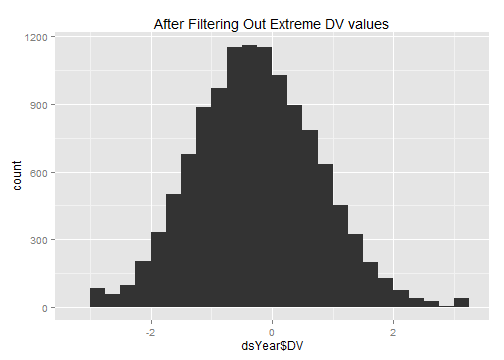

```r
qplot(dsYear$DV, binwidth=.25, main="After Filtering Out Extreme DV values")
```

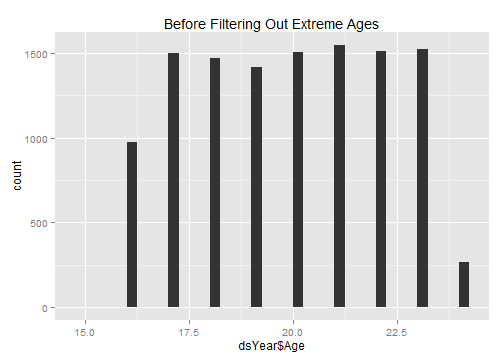

```r
#Filter out records with undesired age values
qplot(dsYear$Age, binwidth=.25, main="Before Filtering Out Extreme Ages")
```

```
geom_path: Each group consist of only one observation. Do you need to adjust the group aesthetic?
```

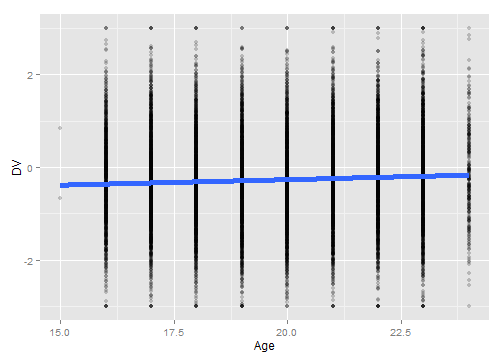

```r
ggplot(dsYear, aes(x=Age, y=DV, group=SubjectTag)) + geom_line(alpha=.2) + geom_point(alpha=.2) + geom_smooth(method="rlm", aes(group=NA), size=2)
```

```r
dsYear <- dsYear[!is.na(dsYear$Age), ]
dsYear <- dsYear[ageMin <= dsYear$Age & dsYear$Age <= ageMax, ]
nrow(dsYear)
```

```
[1] 11719
```

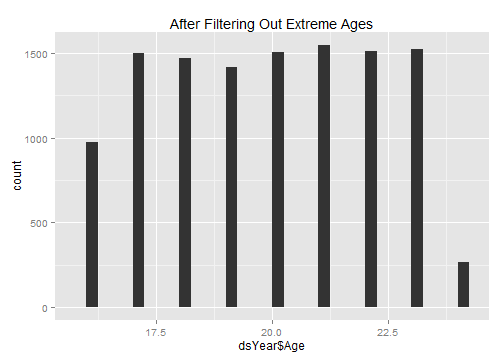

```r
qplot(dsYear$Age, binwidth=.25, main="After Filtering Out Extreme Ages")
```

```
geom_path: Each group consist of only one observation. Do you need to adjust the group aesthetic?
```

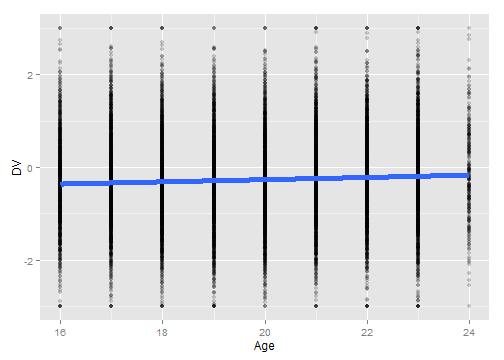

```r
ggplot(dsYear, aes(x=Age, y=DV, group=SubjectTag)) + geom_line(alpha=.2) + geom_point(alpha=.2) + geom_smooth(method="rlm", aes(group=NA), size=2)
```

```r
####################################################################################
```

## Standardize by Gender & Age. Calculated Age (using SurveyDate and MOB) has been truncated to integers.

```r
# dsYear <- ddply(dsYear, c("Gender"), transform, ZGenderAge=scale(DV))  #WATCH OUT-This is a quick hack with age.
dsYear <- ddply(dsYear, c("Gender", "Age"), transform, ZGenderAge=scale(DV))
# dsYear$ZGenderAge <- dsYear$DV
nrow(dsYear)
```

```
[1] 11719
```

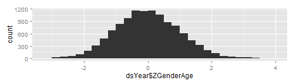

```r
qplot(dsYear$ZGenderAge, binwidth=.25)
```

```r
# dsYear$ZGenderAge <- rnorm(n=nrow(dsYear))

####################################################################################
```

## Determine Z-score to clip at. Adjust as necessary (zMin & zMax were defined at the top of the page). The white box extends between zMin and zMax.

```
geom_path: Each group consist of only one observation. Do you need to adjust the group aesthetic?
```

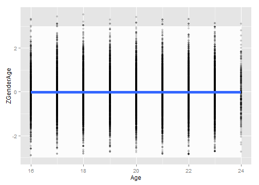

```r
ggplot(dsYear, aes(x=Age, y=ZGenderAge, group=SubjectTag)) +
  annotate("rect", xmin=min(dsYear$Age), xmax=max(dsYear$Age), ymin=zMin, ymax= zMax, fill="gray99") +
  geom_line(alpha=.2) + geom_point(alpha=.2) + geom_smooth(method="rlm", aes(group=NA), size=2)
```

```r
dsYear <- dsYear[zMin <= dsYear$ZGenderAge & dsYear$ZGenderAge <= zMax, ]
nrow(dsYear)
```

```
[1] 11680
```

```
geom_path: Each group consist of only one observation. Do you need to adjust the group aesthetic?
```

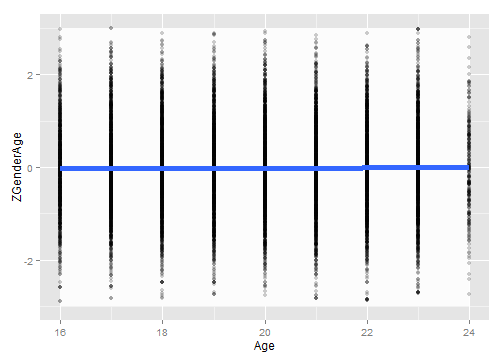

```r
ggplot(dsYear, aes(x=Age, y=ZGenderAge, group=SubjectTag)) +
  annotate("rect", xmin=min(dsYear$Age), xmax=max(dsYear$Age), ymin=zMin, ymax= zMax, fill="gray99") +
  geom_line(alpha=.2) + geom_point(alpha=.2) + geom_smooth(method="rlm", aes(group=NA), size=2)
```

```r
####################################################################################
```

## Pick the subject's oldest record (within that age window). Then examine the age & Z values

```r
#The ASFT was asked only once of the Gen1 subjects, so I don't need to reduce.
ds <- dsYear

ds <- plyr::join(x=dsSubject, y=ds, by="SubjectTag", type="left", match="first")
nrow(ds)
```

```
[1] 12686
```

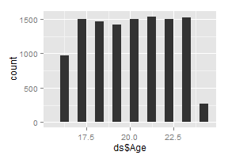

```r
qplot(ds$Age, binwidth=.5) #Make sure ages are within window, and favoring older values
```

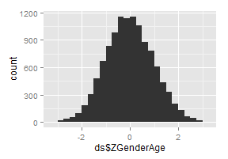

```r
qplot(ds$ZGenderAge, binwidth=.25)
```

```r
table(is.na(ds$ZGenderAge))
```

```
FALSE  TRUE
11680  1006
```

```r
####################################################################################
```

## Write the OutcomeData to CSV

```r
write.csv(ds, pathOutput, row.names=FALSE)

####################################################################################
```

## NLSY Variables

Each row in the table represents and NLSY variable that was used. The first column is the official “R Number” designated by the NLSY. The remaining columns are values we assigned to help the plumbing and data manipulation.

```r
dsVariable[, c("VariableCode", "SurveyYear", "Item", "ItemLabel", "Generation", "ExtractSource", "ID")]
```

```
  VariableCode SurveyYear Item               ItemLabel Generation ExtractSource   ID
1     R0618301       1981  203 Gen1AfqtScaled3Decimals          1             8 1912
```